# SENDAs Agreement 1 Update 2010-2022

Load administrative data from SENDAs patient, compare information with previous databases and explore new data. Focus on other agreements

Author

Andrés González Santa Cruz

Published

March 8, 2025

# Data Loading and Exploration

## Loading Packages and uniting databases

Proceed to load the necessary packages.

```r
#https://github.com/rstudio/renv/issues/544
#renv falls back to copying rather than symlinking, which is evidently very slow in this configuration.
renv::settings$use.cache(FALSE)

#check if rstools is installed
try(installr::install.Rtools(check_r_update=F))
```

Installing package into ‘E:/Mi unidad/Alvacast/SISTRAT 2023/renv/library/windows/R-4.4/x86_64-w64-mingw32’ (as ‘lib’ is unspecified)

[output not shown]

```r
#change repository to CL
local({
  r <- getOption("repos")
  r["CRAN"] <- "https://cran.dcc.uchile.cl/"
  options(repos=r)
})

if(!require(pacman)){install.packages("pacman");require(pacman)}
```

Cargando paquete requerido: pacman

```r
pacman::p_unlock(lib.loc = .libPaths()) #para no tener problemas reinstalando paquetes
```

No 00LOCK detected in: E:/Mi unidad/Alvacast/SISTRAT 2023/renv/library/windows/R-4.4/x86_64-w64-mingw32 No 00LOCK detected in: C:/Program Files/R/R-4.4.0/library

```r
if(Sys.info()["sysname"]=="Windows"){
if (getRversion() != "4.4.0") { stop("Requires R version 4.4.0; Actual: ", getRversion()) }
}

#_#_#_#_#_#_#_#_#_#_#_#_#_#_#_#_#_#_#_#_#_#_#_#_#_#_#_#_#_#_#_#_#_#_#_#_#_#_#_#_
#PACKAGES#######################################################################
#_#_#_#_#_#_#_#_#_#_#_#_#_#_#_#_#_#_#_#_#_#_#_#_#_#_#_#_#_#_#_#_#_#_#_#_#_#_#_#_

unlink("*_cache", recursive=T)

#Package to bring packages in development
if(!require(devtools)){install.packages("devtools")}
```

Cargando paquete requerido: devtools

Cargando paquete requerido: usethis

```r
#Package administration
if(!require(renv)){install.packages("renv")}
```

Cargando paquete requerido: renv

Warning: package ‘renv’ was built under R version 4.4.3

Adjuntando el paquete: ‘renv’

The following object is masked from ‘package:devtools’:

```
install
```

The following objects are masked from ‘package:stats’:

```
embed, update
```

The following objects are masked from ‘package:utils’:

```
history, upgrade
```

The following objects are masked from ‘package:base’:

```
autoload, load, remove, use
```

```r
#To manipulate data
if(!require(tidyverse)){install.packages("tidyverse")}
```

Cargando paquete requerido: tidyverse

Warning: package ‘tidyverse’ was built under R version 4.4.1

```r
if(!require(janitor)){install.packages("janitor")}
```

Cargando paquete requerido: janitor

Adjuntando el paquete: ‘janitor’

The following objects are masked from ‘package:stats’:

```
chisq.test, fisher.test
```

```r
if(!require(plyr)){install.packages("plyr")}
```

## Cargando paquete requerido: plyr

Adjuntando el paquete: ‘plyr’

The following objects are masked from ‘package:dplyr’:

```
arrange, count, desc, failwith, id, mutate, rename, summarise,
summarize
```

The following object is masked from ‘package:purrr’:

```
compact
```

```r
#For contingency tables
if(!require(kableExtra)){install.packages("kableExtra")}
```

Cargando paquete requerido: kableExtra

Warning: package ‘kableExtra’ was built under R version 4.4.2

Adjuntando el paquete: ‘kableExtra’

The following object is masked from ‘package:dplyr’:

```
group_rows
```

```r
#For connections with python
if(!require(reticulate)){install.packages("reticulate")}
```

Cargando paquete requerido: reticulate

Adjuntando el paquete: ‘reticulate’

The following object is masked from ‘package:renv’:

```
use_python
```

```r
#To manipulate big data
if(!require(polars)){install.packages("polars", repos = "https://community.r-multiverse.org")}
```

Cargando paquete requerido: polars

Warning: package ‘polars’ was built under R version 4.4.3

```r
#To bring big databases
if(!require(nanoparquet)){install.packages("nanoparquet")}
```

Cargando paquete requerido: nanoparquet

```r
#interface for rstudio in R
if(!require(rstudioapi)){install.packages("rstudioapi")}
```

Cargando paquete requerido: rstudioapi

Warning: package ‘rstudioapi’ was built under R version 4.4.2

```r
#time handling
if(!require(clock)){install.packages("clock")}
```

Cargando paquete requerido: clock

Adjuntando el paquete: ‘clock’

The following object is masked from ‘package:lubridate’:

```
as_date
```

```r
#combine plots
if(!require(ggpubr)){install.packages("ggpubr")}
```

Cargando paquete requerido: ggpubr

Adjuntando el paquete: ‘ggpubr’

The following object is masked from ‘package:plyr’:

```
mutate
```

```r
#parallelized iterative processing
if(!require(furrr)){install.packages("furrr")}
```

Cargando paquete requerido: furrr Cargando paquete requerido: future

Adjuntando el paquete: ‘future’

The following object is masked from ‘package:renv’:

```
run
```

```r
#work like a tibble with a data.table database
if(!require(tidytable)){install.packages("tidytable")}
```

Cargando paquete requerido: tidytable

Warning: package ‘tidytable’ was built under R version 4.4.1

Adjuntando el paquete: ‘tidytable’

The following objects are masked from ‘package:ggpubr’:

```
group_by, mutate
```

The following objects are masked from ‘package:plyr’:

```
arrange, count, desc, mutate, rename, summarise, summarize
```

The following objects are masked from ‘package:dplyr’:

[output not shown]

The following objects are masked from ‘package:purrr’:

[output not shown]

The following objects are masked from ‘package:tidyr’:

[output not shown]

The following objects are masked from ‘package:tibble’:

```
enframe, tribble
```

The following objects are masked from ‘package:stats’:

```
dt, filter, lag
```

The following object is masked from ‘package:base’:

```
%in%
```

```r
# pacman::p_load(
#   altair, arrow, biostat3, car, caret, chilemapas, choroplethr, choroplethrAdmin1,
#   choroplethrMaps, codebook, compareGroups, DiagrammeR, DiagrammeRsvg, DT, epiR, epitools,
#   factoextra, FactoMineR, finalfit, flexsurv, fmsb, ggfortify, ggiraph, ggiraphExtra,
#   ggpubr, ggrepel, glca, gridExtra, here, Hmisc, htmlwidgets, installr, janitor, kableExtra,
#   lsmeans, magick, matrixStats, Metrics, muhaz, naniar, neuralnet, NeuralNetTools, pagedown,
#   panelr, patchwork, pdp, plotly, plyr, plotly, posterdown, polycor, pROC, psych, radiant,
#   rateratio.test, reshape, reshape2, reticulate, rio, ROCit, rnaturalearth, rsvg, sf, sjPlot,
#   sqldf, Statamarkdown, survminer, survMisc, tableone, tidylog, tidyverse, treemapify, VIM,
#   webshot, xaringanthemer, zoo, install=T
# )


#_#_#_#_#_#_#_#_#_#_#_#_#_#_#_#_#_#_#_#_#_#_#_#_#_#_#_#_#_#_#_#_#_#_#_#_#_#_#_#_
#FUNCTIONS######################################################################
#_#_#_#_#_#_#_#_#_#_#_#_#_#_#_#_#_#_#_#_#_#_#_#_#_#_#_#_#_#_#_#_#_#_#_#_#_#_#_#_

copiar_nombres <- function(x,row.names=FALSE,col.names=TRUE,dec=",",...) {
  if(class(try(dplyr::ungroup(x)))[1]=="tbl_df"){
    if(options()$OutDec=="."){
      options(OutDec = dec)
      write.table(format(data.frame(x)),"clipboard",sep="\t",row.names=FALSE,col.names=col.names,...)
      options(OutDec = ".")
      return(x)
    } else {
      options(OutDec = ",")
      write.table(format(data.frame(x)),"clipboard",sep="\t",row.names=FALSE,col.names=col.names,...)
      options(OutDec = ",")
      return(x)
    }
  } else {
    if(options()$OutDec=="."){
      options(OutDec = dec)
      write.table(format(x),"clipboard",sep="\t",row.names=FALSE,col.names=col.names,...)
      options(OutDec = ".")
      return(x)
    } else {
      options(OutDec = ",")
      write.table(format(x),"clipboard",sep="\t",row.names=FALSE,col.names=col.names,...)
      options(OutDec = ",")
      return(x)
    }
  }
}

#WINDOWS do not restrict memory size
if(.Platform$OS.type == "windows") withAutoprint({
  memory.size()
  memory.size(TRUE)
  memory.limit()
})
```

```
> memory.size()
```

Warning: ‘memory.size()’ is no longer supported

```
[1] Inf
> memory.size(TRUE)
```

Warning: ‘memory.size()’ is no longer supported

```
[1] Inf
> memory.limit()
```

Warning: ‘memory.limit()’ is no longer supported

```
[1] Inf
```

```r
memory.limit(size=56000)
```

Warning: ‘memory.limit()’ is no longer supported

```
[1] Inf
```

```r
#:#:#:#:#:#:#:#:#:#:#:#:#:#:#:#:#:#:#:#:#:#:#:#:#:#:#:#:#:#:#:#:#:#:#:#:#:#:#:#:#:#:#:#:#:#:#:#:#:#:#:#:#:#:#:
#NAs are replaced with "" in knitr kable
options(knitr.kable.NA = '')

#:#:#:#:#:#:#:#:#:#:#:#:#:#:#:#:#:#:#:#:#:#:#:#:#:#:#:#:#:#:#:#:#:#:#:#:#:#:#:#:#:#:#:#:#:#:#:#:#:#:#:#:#:#:#:
#to format rows in bold
format_cells <- function(df, rows ,cols, value = c("italics", "bold", "strikethrough")){

  # select the correct markup
  # one * for italics, two ** for bold
  map <- setNames(c("*", "**", "~~"), c("italics", "bold", "strikethrough"))
  markup <- map[value]

  for (r in rows){
    for(c in cols){

      # Make sure values are not factors
      df[[c]] <- as.character( df[[c]])

      # Update formatting
      df[r, c] <- ifelse(nchar(df[r, c])==0,"",paste0(markup, gsub(" ", "", df[r, c]), markup))
    }
  }

  return(df)
}
#To produce line breaks in messages and warnings
knitr::knit_hooks$set(
   error = function(x, options) {
     paste('\n\n<div class="alert alert-danger" style="font-size: 0.7rem !important;">',
           gsub('##', '\n', gsub('^##\ Error', '**Error**', x)),
           '</div>', sep = '\n')
   },
   warning = function(x, options) {
     paste('\n\n<div class="alert alert-warning" style="font-size: 0.7rem !important;">',
           gsub('##', '\n', gsub('^##\ Warning:', '**Warning**', x)),
           '</div>', sep = '\n')
   },
   message = function(x, options) {
     paste('<div class="message" style="font-size: 0.7rem !important;">',
           gsub('##', '\n', x),
           '</div>', sep = '\n')
   }
)


#_#_#_#_#_#_#_#_#_#_#_#_#_#_#_#_#_#_#_#_#_#_#_#_#_#_#_#_#_#_#_#_#_#_#_#_#_#_#_#_
#CONFIG #######################################################################
#_#_#_#_#_#_#_#_#_#_#_#_#_#_#_#_#_#_#_#_#_#_#_#_#_#_#_#_#_#_#_#_#_#_#_#_#_#_#_#_

options(scipen=2) #display numbers rather scientific number

#_#_#_#_#_#_#_#_#_#_#_#_#_#_#_#_#_#_#_#_#_#_#_#_#_#_#_#_#_#_#_#_#_#_#_#_#_#_#_#_
#ENCODING#######################################################################
#_#_#_#_#_#_#_#_#_#_#_#_#_#_#_#_#_#_#_#_#_#_#_#_#_#_#_#_#_#_#_#_#_#_#_#_#_#_#_#_

conv_chars <- data.frame(
    ANSI = c("Á", "á", "É", "é", "Í", "í", "Ó", "ó", "Ú", "ú", "Ñ", "ñ", "¿", "ó"),
    UTF_8 = c("Ã", "Ã¡", "Ã‰", "Ã©", "Ã", "Ã", "Ã“", "Ã³", "Ãš", "Ãº", "Ã‘", "Ã±", "Â¿", "Ã²"),
    JAVASCRIPT = c("u00c1", "u00e1", "u00c9", "u00e9", "u00cd", "u00ed", "u00d3", "u00f3", "u00da", "u00fa", "u00d1", "u00f1", "u00bf", "0xF2"),
    HTML = c("&#193;", "&#225;", "&#201;", "&#233;", "&#205;", "&#237;", "&#211;", "&#243;", "&#218;", "&#250;", "&#209;", "&#241;", "&#191;", "")
)

convert_chars <- function(x) {
    x <- gsub("ÃƒÂ³", "ó", x)  # ó
    x <- gsub("ÃƒÂ¡", "á", x)  # á
    x <- gsub("ÃƒÂ©", "é", x)  # é
    x <- gsub("ÃƒÂº", "ú", x)  # ú
    x <- gsub("ÃƒÂ±", "ñ", x)  # ñ
    x <- gsub("Ãƒâ€˜", "Ñ", x) # Ñ (mayúscula)
    x <- gsub("ÃƒÂ", "Á", x)   # Á
    x <- gsub("Ã‚Âº", "º", x)  # º
    x <- gsub("Ã‚Â°", "°", x)  # °
    x <- gsub("Ã‚Âª", "ª", x)  # ª
    x <- gsub("Ã‚Â¡", "¡", x)  # ¡
    x <- gsub("Ã‚Â¿", "¿", x)  # ¿
    x <- gsub("ÃƒÂ", "í", x)  # í
    x <- gsub("Ãƒâ€œ", "Ó", x)  # Ó
    x <- gsub("Ãƒâ€š", "Ê", x)  # Ê
    x <- gsub("Ãƒâ€", "É", x)  # É
    x <- gsub("ÃƒÂ¼", "ü", x)  # ü
    x <- gsub("ÃƒÂ¯", "ï", x)  # ï
    x <- gsub("ÃƒÂ¶", "ö", x)  # ö
    x <- gsub("Ã‚Â«", "«", x)  # «
    x <- gsub("Ã‚Â»", "»", x)  # »
    x <- gsub("Ãƒâ€¡", "Ç", x)  # Ç
    x <- gsub("ÃƒÂ§", "ç", x)  # ç
    x <- gsub("Ã‚Â", "", x)    # Otros casos residuales
    x <- gsub("Ãƒ", "", x)     # Otros casos residuales
    return(x)
}

sum_dates <- function(x){

  cbind.data.frame(
min= as.Date(min(unclass(as.Date(x)), na.rm=T), origin = "1970-01-01"),
p001= as.Date(quantile(unclass(as.Date(x)), .001, na.rm=T), origin = "1970-01-01"),
p005= as.Date(quantile(unclass(as.Date(x)), .005, na.rm=T), origin = "1970-01-01"),
p025= as.Date(quantile(unclass(as.Date(x)), .025, na.rm=T), origin = "1970-01-01"),
p25= as.Date(quantile(unclass(as.Date(x)), .25, na.rm=T), origin = "1970-01-01"),
p50= as.Date(quantile(unclass(as.Date(x)), .5, na.rm=T), origin = "1970-01-01"),
p75= as.Date(quantile(unclass(as.Date(x)), .75, na.rm=T), origin = "1970-01-01"),
p975= as.Date(quantile(unclass(as.Date(x)), .975, na.rm=T), origin = "1970-01-01"),
p995= as.Date(quantile(unclass(as.Date(x)), .995, na.rm=T), origin = "1970-01-01"),
p999= as.Date(quantile(unclass(as.Date(x)), .999, na.rm=T), origin = "1970-01-01"),
max= as.Date(max(unclass(as.Date(x)), na.rm=T), origin = "1970-01-01")
  )
}

# Define the function adapted for Polars
sum_dates_polars <- function(df, date_col) {
  # Create the list of quantiles
  quantiles <- c(0.001, 0.005, 0.025, 0.25, 0.5, 0.75, 0.975, 0.995, 0.999)
  # Create expressions to calculate min and max
  expr_list <- list(
    pl$col(date_col)$min()$alias("min"),
    pl$col(date_col)$max()$alias("max")
  )
  # Add expressions for quantiles
  for (q in quantiles) {
    expr_list <- append(expr_list, pl$col(date_col)$quantile(q)$alias(paste0("p", sub("\\.", "", as.character(q)))))
  }
  # Apply the expressions and return a DataFrame with the results
  df$select(expr_list)
}
```

### C2-C6

SENDA has the following treatment programs:

- General Adult Program (covered in Agreement 1 or C1)
- Specific Women’s Program (covered in Agreement 1 or C1)
- Street Program
- General Children and Adolescents Program
- Probation Program
- Adolescent Offenders Program
- Adult Offenders Program

*(Source: https://www.senda.gob.cl/wp-content/uploads/2022/05/Cuenta-Publica-SENDA-2022.pdf)*

```r
#E:\Mi unidad\Alvacast\SISTRAT 2023\data\20231018_original_data
dir_c2_c6<-paste0(gsub("22","19",path),"/Encriptados c2 a c6/")

# Define the directories
dir_c2_c6_oct <- paste0(gsub("cons", "",
                             paste0(getwd(),"cons")
), "data/20231018_original_data/")

#matches a string that starts with c
SISTRAT23_c26<-list.files(path=toString(dir_c2_c6_oct), pattern="^c")


# Function to simplify pattern matching
matches_pattern <- function(x, patterns) {
  any(sapply(patterns, function(p) grepl(p, x)))
}

# Create a function to process each file
process_file <- function(dir, x) {
  # Determine the HASH_KEY index based on file name
  prefix <- ifelse(matches_pattern(x, "dup1"), "SISTRAT23dup1_",
                   ifelse(matches_pattern(x, "dup2"), "SISTRAT23dup2_", "SISTRAT23_"))

  # Read and process the file
  dataset<-readr::read_delim(paste0(dir, x),
                             na = c("", "NA", "null"),
                             locale = locale(encoding = "windows-1252"),
                             guess_max = min(1e5, Inf),
                             skip = 0)
  colnames(dataset) <- sapply(names(dataset), convert_chars)

  dataset %>%
    janitor::clean_names() %>%
    dplyr::rename(
      HASH_KEY = !!names(.[(ncol(.))])) %>%
    dplyr::mutate(TABLE = rep(x)) %>%
    dplyr::select(TABLE, HASH_KEY, everything()) %>%
    assign(paste0(prefix, stringr::str_sub(x, 1, 4)), ., envir = .GlobalEnv)
}

#Read data and format
purrr::walk(SISTRAT23_c26, ~process_file(toString(dir_c2_c6_oct), .x))
```

ℹ Use `spec()` to retrieve the full column specification for this data. ℹ Specify the column types or set `show_col_types = FALSE` to quiet this message.

```r
# Process C2-C6 data
CONS_C2 <- plyr::rbind.fill(SISTRAT23dup1_c2_o, SISTRAT23dup2_c2_o) %>%
  data.table::data.table() %>%
  dplyr::mutate(TABLE = substr(TABLE, start=1, stop=2))

CONS_C3 <- SISTRAT23_c3_o %>% dplyr::mutate(TABLE = substr(TABLE, start=1, stop=2))
CONS_C4 <- SISTRAT23_c4_o %>% dplyr::mutate(TABLE = substr(TABLE, start=1, stop=2))
CONS_C5 <- SISTRAT23_c5_o %>% dplyr::mutate(TABLE = substr(TABLE, start=1, stop=2))
CONS_C6 <- SISTRAT23_c6_o %>% dplyr::mutate(TABLE = substr(TABLE, start=1, stop=2))
```

```r
CONS_C6$edad_ingreso<-
as.numeric(round((parse_date(CONS_C6$fechaingresotratamiento,"%d/%m/%Y")-parse_date(CONS_C6$fechanacimiento,"%d/%m/%Y"))/365.25,3))


# Create the histograms for each dataset
hist_c2 <- ggplot(CONS_C2, aes(x = edad)) +
  geom_histogram(fill = "gray70", color = "black", bins = 30) +
  ggtitle("c2")+ theme_bw()+ xlim(0,90)

hist_c3 <- ggplot(CONS_C3, aes(x = edad)) +
  geom_histogram(fill = "gray70", color = "black", bins = 30) +
  ggtitle("c3")+ theme_bw()+ xlim(0,90)

hist_c4 <- ggplot(CONS_C4, aes(x = edad)) +
  geom_histogram(fill = "gray70", color = "black", bins = 30) +
  ggtitle("c4")+ theme_bw()+ xlim(0,90)

hist_c5 <- ggplot(CONS_C5, aes(x = edad)) +
  geom_histogram(fill = "gray70", color = "black", bins = 30) +
  ggtitle("c5")+ theme_bw()+ xlim(0,90)

hist_c6 <- ggplot(CONS_C6, aes(x = edad_ingreso)) +
  geom_histogram(fill = "gray70", color = "black", bins = 30) +
  ggtitle("c6")+ theme_bw()+ xlim(0,90)

# Combine histograms into a single plot
combined_plot <- ggpubr::ggarrange(hist_c2, hist_c3, hist_c4, hist_c5, hist_c6, ncol = 3, nrow = 2)
```

Warning: Removed 1 row containing non-finite outside the scale range (`stat_bin()`).

Warning: Removed 1 row containing non-finite outside the scale range (`stat_bin()`).

Histograms for Age

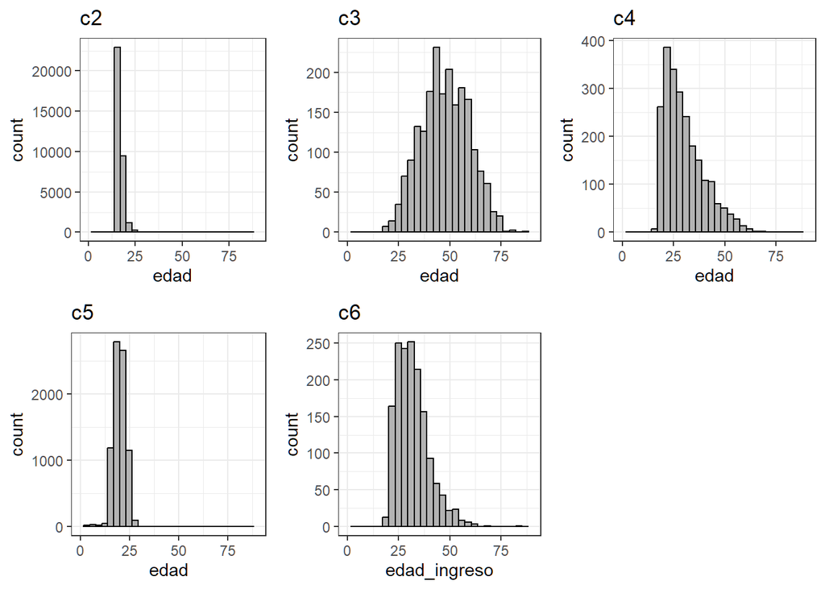

```r
# Display the combined plot
print(combined_plot)
```

```r
# Get the column names for each dataset
names_c2 <- names(CONS_C2)
names_c3 <- names(CONS_C3)
names_c4 <- names(CONS_C4)
names_c5 <- names(CONS_C5)
names_c6 <- names(CONS_C6)

df_c2 <- data.frame(Dataset = "CONS_C2", Column_Name = names_c2)
df_c3 <- data.frame(Dataset = "CONS_C3", Column_Name = names_c3)
df_c4 <- data.frame(Dataset = "CONS_C4", Column_Name = names_c4)
df_c5 <- data.frame(Dataset = "CONS_C5", Column_Name = names_c5)
df_c6 <- data.frame(Dataset = "CONS_C6", Column_Name = names_c6)

dplyr::full_join(df_c2, df_c3, by = "Column_Name") %>%
    dplyr::full_join(df_c4, by = "Column_Name") %>%
    dplyr::full_join(df_c5, by = "Column_Name") %>%
    dplyr::full_join(df_c6, by = "Column_Name") %>%
    dplyr::arrange(Column_Name) -> joined_df

joined_df %>%
  dplyr::select(Column_Name, everything()) %>%
  dplyr::arrange(Column_Name) %>%
  dplyr::rename("c2"="Dataset.x","c3"="Dataset.y", "c4"="Dataset.x.x", "c5"="Dataset.y.y","c6"="Dataset") %>%
  dplyr::mutate_at(.vars = vars(matches("c[0-9]$")),
                        .funs = ~ ifelse(!is.na(.), "X", "")) %>%
  kbl("markdown", caption="Replicated Fields in Databases")
```

Replicated Fields in Databases

| Column_Name | c2 | c3 | c4 | c5 | c6 |
| --- | --- | --- | --- | --- | --- |
| HASH_KEY | X | X | X | X | X |
| TABLE | X | X | X | X | X |
| a_afos_deserci_afn_escolar | X |  |  | X |  |
| a_setratadeunamujerembaraza | X |  |  |  |  |
| actualmenteen_sistema_escolar | X |  |  | X |  |
| an |  |  |  |  | X |
| antecedentes_penales |  |  |  | X |  |
| ao |  |  | X |  |  |
| ap |  |  | X |  |  |
| aplicacia_nigi |  |  |  |  | X |
| ar |  | X | X |  |  |
| as |  |  | X |  |  |
| asistencia_senameegreso |  |  |  | X |  |
| asistencia_senameingreso |  |  |  | X |  |
| au |  |  |  |  | X |
| av |  |  | X |  | X |
| aw |  | X |  |  |  |
| ax |  |  |  |  | X |
| ay |  |  |  |  | X |
| ba |  |  | X |  | X |
| bb |  |  | X |  |  |
| be |  |  |  | X |  |
| bf |  |  | X |  |  |
| bg |  |  |  | X |  |
| bh |  | X |  | X |  |
| bi | X |  |  | X |  |
| bj |  | X | X | X |  |
| bk |  |  | X | X |  |
| bl |  |  | X |  |  |
| bm |  |  | X | X |  |

[output cut: 230 more lines]

We can see the following from C2-C6 databases that share different names.

Columns with only 2 letters or less (presumably generated by Excel based on their position) were renamed to follow a sequential format. Each of these 2-letter columns was renamed using the name of the previous column followed by a sequential number. This helps in making the column names more meaningful and maintaining a clear, organized structure, especially when the original names may have been automatically generated or lacked context.

```r
rename_short_columns <- function(df) {
  col_names <- names(df)  # Get column names
  base_name <- col_names[1]  # Start with the first column name as base
  counter <- 2               # Start numbering from 2 for additional columns

  for (i in 2:length(col_names)) {
    if (nchar(col_names[i]) <= 2) {  # Check if the column name has only 2 characters
      col_names[i] <- paste0(base_name, "_", counter)  # Use base name + sequential number
      counter <- counter + 1  # Increment the counter
    } else {
      base_name <- col_names[i]  # Update the base name to the current column name
      counter <- 2               # Reset counter for the next series of short columns
    }
  }

  names(df) <- col_names  # Assign the new column names to the DataFrame
  return(df)
}
# Applying the function
SISTRAT23_c1_2010_2022_df2 <- rename_short_columns(SISTRAT23_c1_2010_2022_df2)
CONS_C2 <- rename_short_columns(CONS_C2)
CONS_C3 <- rename_short_columns(CONS_C3)
CONS_C4 <- rename_short_columns(CONS_C4)
CONS_C5 <- rename_short_columns(CONS_C5)
CONS_C6 <- rename_short_columns(CONS_C6)
```

```r
rbind(
    cbind("c2_AdmDate_min",min(readr::parse_date(CONS_C2$fecha_ingreso_tratamiento,"%d/%m/%Y"),na.rm=T)),
    cbind("c2_AdmDate_max",max(readr::parse_date(CONS_C2$fecha_ingreso_tratamiento,"%d/%m/%Y"),na.rm=T)),
    cbind("c2_DischDate_min",min(readr::parse_date(CONS_C2$fecha_egreso,"%d/%m/%Y"),na.rm=T)),
    cbind("c2_DischDate_max",max(readr::parse_date(CONS_C2$fecha_egreso,"%d/%m/%Y"),na.rm=T)),
    cbind("c2_BirthDate_min",min(readr::parse_date(CONS_C2$fecha_nacimiento,"%d/%m/%Y"),na.rm=T)),
    cbind("c2_BirthDate_max",max(readr::parse_date(CONS_C2$fecha_nacimiento,"%d/%m/%Y"),na.rm=T)),

    cbind("c3_AdmDate_min",min(readr::parse_date(CONS_C3$fecha_ingresoa_tratamiento,"%d/%m/%Y"),na.rm=T)),
    cbind("c3_AdmDate_max",max(readr::parse_date(CONS_C3$fecha_ingresoa_tratamiento,"%d/%m/%Y"),na.rm=T)),
    cbind("c3_DischDate_min",min(readr::parse_date(CONS_C3$fecha_ingresoa_tratamiento,"%d/%m/%Y"),na.rm=T)),
    cbind("c3_DischDate_max",max(readr::parse_date(CONS_C3$fecha_ingresoa_tratamiento,"%d/%m/%Y"),na.rm=T)),

    cbind("c4_AdmDate_min",min(readr::parse_date(CONS_C4$fechaingresotratamiento,"%d/%m/%Y"),na.rm=T)),
    cbind("c4_AdmDate_max",max(readr::parse_date(CONS_C4$fechaingresotratamiento,"%d/%m/%Y"),na.rm=T)),
    cbind("c4_DischDate_min",min(readr::parse_date(CONS_C4$fechaegresotratamiento,"%d/%m/%Y"),na.rm=T)),
    cbind("c4_DischDate_max",max(readr::parse_date(CONS_C4$fechaegresotratamiento,"%d/%m/%Y"),na.rm=T)),
    cbind("c4_BirthDate_min",min(readr::parse_date(CONS_C4$fechanacimiento,"%d/%m/%Y"),na.rm=T)),
    cbind("c4_BirthDate_max",max(readr::parse_date(CONS_C4$fechanacimiento,"%d/%m/%Y"),na.rm=T)),

    cbind("c5_AdmDate_min",min(readr::parse_date(CONS_C5$fecha_ingreso_tratamiento,"%d/%m/%Y"),na.rm=T)),
    cbind("c5_AdmDate_max",max(readr::parse_date(CONS_C5$fecha_ingreso_tratamiento,"%d/%m/%Y"),na.rm=T)),
    cbind("c5_DischDate_min",min(readr::parse_date(CONS_C5$fecha_egreso,"%d/%m/%Y"),na.rm=T)),
    cbind("c5_DischDate_max",max(readr::parse_date(CONS_C5$fecha_egreso,"%d/%m/%Y"),na.rm=T)),
    cbind("c5_BirthDate_min",min(readr::parse_date(CONS_C5$fecha_nacimiento,"%d/%m/%Y"),na.rm=T)),
    cbind("c5_BirthDate_max",max(readr::parse_date(CONS_C5$fecha_nacimiento,"%d/%m/%Y"),na.rm=T)),

    cbind("c6_AdmDate_min",min(readr::parse_date(CONS_C6$fechaingresotratamiento,"%d/%m/%Y"),na.rm=T)),
    cbind("c6_AdmDate_max",max(readr::parse_date(CONS_C6$fechaingresotratamiento,"%d/%m/%Y"),na.rm=T)),
    cbind("c6_DischDate_min",min(readr::parse_date(CONS_C6$fechaegresotratamiento,"%d/%m/%Y"),na.rm=T)),
    cbind("c6_DischDate_max",max(readr::parse_date(CONS_C6$fechaegresotratamiento,"%d/%m/%Y"),na.rm=T)),
    cbind("c6_BirthDate_min",min(readr::parse_date(CONS_C6$fechanacimiento,"%d/%m/%Y"),na.rm=T)),
    cbind("c6_BirthDate_max",max(readr::parse_date(CONS_C6$fechanacimiento,"%d/%m/%Y"),na.rm=T))
) %>%
    data.frame() %>%
    dplyr::rename("Date"="X2") %>%
    tidyr::separate(X1,sep="_", into=c("db","time","value")) %>%
    dplyr::mutate(Date=as.Date(as.numeric(Date),origin = "1970-01-01")) %>%
    tidyr::pivot_wider(names_from=value, values_from=Date) %>%
  kbl("markdown", caption= "Range of dates in different databases")
```

Range of dates in different databases

| db | time | min | max |
| --- | --- | --- | --- |
| c2 | AdmDate | 2009-11-02 | 2022-12-20 |
| c2 | DischDate | 2014-01-02 | 2023-04-28 |
| c2 | BirthDate | 1983-06-30 | 2008-10-08 |
| c3 | AdmDate | 2011-02-07 | 2022-12-19 |
| c3 | DischDate | 2011-02-07 | 2022-12-19 |
| c4 | AdmDate | 2002-01-01 | 2022-12-19 |
| c4 | DischDate | 2014-07-24 | 2023-04-24 |
| c4 | BirthDate | 1949-09-19 | 2014-12-09 |
| c5 | AdmDate | 2013-01-02 | 2022-12-20 |
| c5 | DischDate | 2014-05-02 | 2023-04-30 |
| c5 | BirthDate | 1994-01-06 | 2022-11-17 |
| c6 | AdmDate | 2015-06-02 | 2022-02-07 |
| c6 | DischDate | 2017-05-06 | 2023-04-19 |
| c6 | BirthDate | 1936-10-27 | 2018-06-09 |

Next, we standardized column names from `CONS_C2` to `CONS_C6`, by setting specific patterns and replacements for each dataset (`CONS_C2` to `CONS_C6`), tailored to each dataset’s needs (e.g., `_afn` to `on` in `CONS_C2`). Then, we applied both specific and general patterns to column names in each dataset, ensuring consistent naming to replace patterns systematically across all column names.

```r
# Define los patrones y reemplazos para cada DataFrame
patterns_C2 <- c("_afn", "n_afomero", "a_afos")
replacements_C2 <- c("on", "numero", "anios")

patterns_C3 <- c("pa_a_s", "fa_sico", "categor_a_a")
replacements_C3 <- c("pais", "fisico", "categoria")

patterns_C4 <- c("aa_o")
replacements_C4 <- c("anio")

patterns_C5 <- c("psiqui_aftrico", "s_afndromede")
replacements_C5 <- c("psiquiatrico", "sindrome")

patterns_C6 <- c("aa_o", "viva_a", "sustanci_an", "n_as_mero", "aa_o", "da_as", "aplicacia_n")
replacements_C6 <- c("anio", "vivia", "sustancia_n", "numero", "anio", "dias", "aplicacion")

patterns <- c(patterns_C2, patterns_C3, patterns_C4, patterns_C5, patterns_C6)
replacements <-c(replacements_C2, replacements_C3, replacements_C4, replacements_C5, replacements_C6)

for (i in seq_along(patterns)) {
  colnames(CONS_C2) <- sub(patterns[i], replacements[i], colnames(CONS_C2))
  colnames(CONS_C3) <- sub(patterns[i], replacements[i], colnames(CONS_C3))
  colnames(CONS_C4) <- sub(patterns[i], replacements[i], colnames(CONS_C4))
  colnames(CONS_C5) <- sub(patterns[i], replacements[i], colnames(CONS_C5))
  colnames(CONS_C6) <- sub(patterns[i], replacements[i], colnames(CONS_C6))
}
```

##### Clean C2

```r
# Define a named vector with replacements
replacements <- c(
  "ÃƒÂ³" = "ó", "ÃƒÂ¡" = "á", "ÃƒÂ©" = "é", "ÃƒÂº" = "ú",
  "ÃƒÂ±" = "ñ", "Ãƒâ€˜" = "Ñ", "ÃƒÂ" = "Á", "ÃƒÂ¡" = "á",
  "ÃƒÂ©" = "é", "ÃƒÂº" = "ú", "ÃƒÂ±" = "ñ", "Ãƒâ€˜" = "Ñ",
  "ÃƒÂ" = "Á", "Ã‚Âº" = "º", "Ã‚Â°" = "°", "Ã‚Âª" = "ª",
  "Ã‚Â¡" = "¡", "Ã‚Â¿" = "¿", "ÃƒÂ" = "í", "ÃƒÂ" = "í",
  "Ãƒâ€œ" = "Ó", "Ãƒâ€š" = "Ê", "Ãƒâ€" = "É", "ÃƒÂ¼" = "ü",
  "ÃƒÂ¯" = "ï", "ÃƒÂ¶" = "ö", "Ã‚Â«" = "«", "Ã‚Â»" = "»",
  "Ãƒâ€¡" = "Ç", "ÃƒÂ§" = "ç", "Ã‚Â" = "", "Ãƒ" = "",
  "\u00AD" = "", "\u00C2\u00AD" = ""
)
# Create a function to apply the replacements
replace_chars <- function(column) {
  reduce(names(replacements), ~ str_replace_all(.x, .y, replacements[.y]), .init = column)
}
CONS_C2 <- CONS_C2 %>%
  mutate(across(everything(), replace_chars))

#:#:#:#:#:#:#:#:#:#:#:#:#:#:#:#:#:#:#:#:#:#:#:#:#:#:#:#:#:#:#:#:#:#:#:#:#:#:#:#:#:#:#:#:
##:#:#:#:#:#:#:#:#:#:#:#:#:#:#:#:#:#:#:#:#:#:#:#:#:#:#:#:#:#:#:#:#:#:#:#:#:#:#:#:#:#:#:#:
invisible("Obtain unique values by column")

unique_values_list_c2 <- setNames(
  lapply(names(CONS_C2), function(col_name) {
    # Obtener los valores únicos de la columna
    unique_values <- unique(CONS_C2[[col_name]])
    return(unique_values)
  }),
  names(CONS_C2)  # Asignar los nombres de las columnas a la lista
)
#:#:#:#:#:#:#:#:#:#:#:#:#:#:#:#:#:#:#:#:#:#:#:#:#:#:#:#:#:#:#:#:#:#:#:#:#:#:#:#:#:#:#:#:
##:#:#:#:#:#:#:#:#:#:#:#:#:#:#:#:#:#:#:#:#:#:#:#:#:#:#:#:#:#:#:#:#:#:#:#:#:#:#:#:#:#:#:#:

# Apply transformations to character columns
CONS_C2 <- CONS_C2 %>%
  dplyr::mutate(across(everything(), ~ {
    .x %>%
      stringr::str_to_lower() %>%  # Convert to lowercase
      stringr::str_trim() %>%  # Trim leading and trailing whitespace
      stringr::str_replace_all("\\s+", " ") %>%  # Replace multiple spaces with a single space
      stringr::str_replace_all("\\s*\\.\\s*$", "")  # Remove periods at the end (and spaces before)
  }))

#:#:#:#:#:#:#:#:#:#:#:#:#:#:#:#:#:#:#:#:#:#:#:#:#:#:#:#:#:#:#:#:#:#:#:#:#:#:#:#:#:#:#:#:
##:#:#:#:#:#:#:#:#:#:#:#:#:#:#:#:#:#:#:#:#:#:#:#:#:#:#:#:#:#:#:#:#:#:#:#:#:#:#:#:#:#:#:#:
##

replacements <- c(
  "\u00c2" = "", "viá‘a" = "viña", "reloncavá\u008d" = "reloncavi",
  "maráa" = "maría", "á‘uble" = "ñuble", "vánculos" = "vínculos",
  "concepciá“n" = "concepción", "aysá‰n" = "aysén", "mánimo" = "mínimo",
  "m\\?mo" = "mínimo", "clánica" = "clínica", "prisionizaci\\?" = "prisionalización",
  "explotaci\\?omercial" = "explotación comercial", "patología" = "patología",
  "cardiopatías" = "cardiopatías", "especáfico" = "específico",
  "esquizotápico" = "esquizotípico", "tricotilomanía" = "tricotilomanía",
  "hipomanáaco" = "hipomaníaco", "lámite" = "límite", "manáaco" = "maníaco",
  "á\u0081nimo" = "ánimo", "cleptomanía" = "cleptomanía", "hipocondría" = "hipocondría",
  "raá\u008dces" = "raíces", "raá\\u008dces" = "raíces", "curacavá" = "curacaví",
  "raáces" = "raíces", "terapá‰utica" = "terapéutica", "raáces" = "raíces",
  "\\?ble" = "ñuble", "báo-báo" = "bío-bío", "iba\\?s" = "ibañez",
  "reloncavá" = "reloncaví", "valparaáso" = "valparaíso", "araucanáa" = "araucanía",
  "á‘uble" = "ñuble", "especáfico" = "específico", "vi\\? del mar" = "viña del mar",
  "do\\?hue" = "doñihue", "huala\\?" = "hualaé", "\\?qu\\?" = "ñiquén",
  "cha\\?ral" = "chañaral", "ollag\\?" = "ollagüe", "vicu\\?" = "vicuña",
  "ca\\?te" = "cañete", "\\?\\?a" = "ñuñoa", "policáa" = "policía",
  "garantáa" = "garantía", "fiscaláa" = "fiscalía", "haitá" = "haití",
  "hungráa" = "hungría", "paás bajos" = "países bajos", "atacame\\?" = "atacameño",
  "y\\?na" = "yámana", "y\\?gan" = "yagán", "hipn\\?os" = "hipnóticos",
  "hero\\?" = "heroína", "code\\?" = "codeína", "analg\\?cos" = "analgésicos",
  "barbit\\?os" = "barbitúricos", "alucin\\?os" = "alucinógenos",
  "ãƒâ³n" = "ón", "ãƒâ©n" = "én", "ãƒâº" = "ú", "ãƒâºa" = "úa",
  "ãƒâos" = "íos", "ãƒâuble" = "ñuble", "ãƒâ³n general" = "ón general",
  "ãƒâ" = "í", "ãƒâ³n casa" = "ón casa", "ãƒârbara" = "árbara",
  "naãƒâ" = "ñ", "raãƒâces" = "raíces", "baãƒâsico" = "básico",
  "ãƒâ©utico" = "éutico", "vaãƒânculos" = "vínculos", "marãƒâa" = "maría",
  "inaãƒâ©s" = "inés", "raí\\u008dces" = "raíces", "chiloí©" = "chiloé",
  "terapí©utico" = "terapéutico", "bísico" = "básico", "peí±ablanca" = "peñablanca",
  "iní©s" = "inés", "infracción" = "infracción", "layantú" = "layantu",
  "oriã³n" = "orion", "valparaãso" = "valparaiso", "fãsico" = "fisico",
  "ningãún gãénero" = "ningun genero", "viãña" = "viña",
  "corporación" = "corporacion", "aysã©n" = "aysen", "\tcodesam" = "codesam",
  "corporación" = "corporacion", "concepción" = "concepcion",
  "hábitos" = "habitos", "psíquica" = "psiquica", "neuróticos" = "neuroticos",
  "fisiológicas" = "fisiologicas", "somáticos" = "somaticos",
  "orgánicos" = "organicos", "sintomáticos" = "sintomaticos",
  "psicológico" = "psicologico", "mínimo" = "minimo", "sanción" = "sancion",
  "terapéutica" = "terapeutica", "término" = "termino", "derivación" = "derivacion",
  "prisionalización" = "prisionalizacion", "explotación" = "explotacion",
  "estrés" = "estres", "años" = "años", "dãas"="días", "mãnimo"="minimo","ã©"="e"
)

replace_chars <- function(column) {
  reduce(names(replacements), ~ stringr::str_replace_all(.x, .y, replacements[.y]), .init = column)
}

CONS_C2 <- CONS_C2 %>%
  dplyr::mutate(across(everything(), replace_chars))
#:#:#:#:#:#:#:#:#:#:#:#:#:#:#:#:#:#:#:#:#:#:#:#:#:#:#:#:#:#:#:#:#:#:#:#:#:#:#:#:#:#:#:#:
##:#:#:#:#:#:#:#:#:#:#:#:#:#:#:#:#:#:#:#:#:#:#:#:#:#:#:#:#:#:#:#:#:#:#:#:#:#:#:#:#:#:#:#:
##

unique_values_list_c21 <- setNames(
  lapply(names(CONS_C2), function(col_name) {
    # obtain unique values
    unique_values <- unique(CONS_C2[[col_name]])
    return(unique_values)
  }),
  names(CONS_C2)  # assign column names to the list
)

#1:5
#unique_values_list_c21[27:37]
#:#:#:#:#:#:#:#:#:#:#:#:#:#:#:#:#:#:#:#:#:#:#:#:#:#:#:#:#:#:#:#:#:#:#:#:#:#:#:#:#:#:#:#:
##:#:#:#:#:#:#:#:#:#:#:#:#:#:#:#:#:#:#:#:#:#:#:#:#:#:#:#:#:#:#:#:#:#:#:#:#:#:#:#:#:#:#:#:
# Crear una lista para almacenar las expresiones de reemplazo
replacements3 <- c(
  # "\u00AD" = "", "\u00C2\u00AD" = "", "\u00C2" = "",
  # "ráo negro" = "río negro", "báo-báo" = "bío-bío",
  # "pe\\?lolen" = "peñalolén", "pe\\?flor" = "peñaflor",
  # "san gregorio de \\?quén" = "san gregorio de ñiquén",
  # "\\?o nitroso" = "óxido nitroso", "coca\\?" = "cocaína",
  # "nunca estud¡" = "nunca estudió",
  # "t\\?ica comercial/industrial/normalista" = "técnica comercial/industrial/normalista",
  "profesional \\(4 o m\\?a\\? incompleta" = "profesional (4 o más incompleta)",
  "profesional \\(4 o m\\?a\\? completa" = "profesional (4 o más completa)",
  # "t\\?ica profesional˜" = "técnica profesional",
   "t\\?ico superior \\(1-3 a\\? completa" = "técnico superior (1-3 años completa)",
  # "educaci\\?\\?ca" = "educación básica",
   "t\\?ico superior \\(1-3 a\\? incompleta" = "técnico superior (1-3 años incompleta)",
  # "cientáficos" = "científicos", "ášnicamente" = "únicamente",
  # "hospeder\\?" = "hospedería", "residencial, pensi\\?hostal" = "residencial, pensión, hostal",
  # "ocupaci\\?rregular" = "ocupación irregular", "cocaána" = "cocaína",
  # "heroána" = "heroína", "codeána" = "codeína",
  # "sintomático" = "sintomático", "disfunción" = "disfunción",
  # "lesión" = "lesión", "días" = "días", "orientación" = "orientación",
  # "especificación" = "especificación", "\\tcodesam" = "codesam",
  "cleptomanáa" = "cleptomanía", "tricotilomanáa" = "tricotilomanía",
  "cardiopatáas" = "cardiopatías", "patologáa" = "patología",
  "último" = "últimos", "\\|(\\d+)" = "1", "1o" = "10",
  "aná\u0081stasis"= "anástasis",
  "á‘uá‘oa" = "ñuñoa", "cocaána" = "cocaína", "hospederáa" = "hospedería",
  "ášnicamente" = "únicamente", "t\\?ico" = "técnico", "nunca estudi" = "nunca estudió",
  "t\\?ica"= "técnica", "educaci\\?\\?ca" = "educación básica",
  "dáas" = "días", "dáa" = "día",
   "lesiones gravásimaslesiones gravásimas" = "lesiones gravísimas",
  "táas" = "tías", "táos" = "tíos", "crámenes" = "crímenes",
  "jurádica" = "jurídica", "daá‘o" = "daño", "puchuncavá"= "puchuncaví",
  "suspención" = "suspensión", "á‘iquen" = "ñiquen", "doá‘ihue" = "doñihue",
  "caá‘ete" = "cañete", "vicuá‘a" = "vicuña", "á‘uá‘oa"="ñuñoa",
  "chaá‘aral"= "chañaral", "quilpuá‰"= "quilpué",
  "peá‘alolen" = "peñalolén", "peá‘aflor" = "peñaflor",
  "ibaá‘ez" = "ibáñez", "prisionización" = "prisionalización",
  "piromanáa" = "piromanía", "psicotropas" = "psicotrópicas",
  "fásico" = "físico", "psáquica" = "psíquica"
)
replace_chars <- function(column) {
  reduce(names(replacements3), ~ stringr::str_replace_all(.x, .y, replacements3[.y]), .init = column)
}

CONS_C2 <- CONS_C2 %>%
  dplyr::mutate(across(everything(), replace_chars))
#:#:#:#:#:#:#:#:#:#:#:#:#:#:#:#:#:#:#:#:#:#:#:#:#:#:#:#:#:#:#:#:#:#:#:#:#:#:#:#:#:#:#:#:
##:#:#:#:#:#:#:#:#:#:#:#:#:#:#:#:#:#:#:#:#:#:#:#:#:#:#:#:#:#:#:#:#:#:#:#:#:#:#:#:#:#:#:#:
invisible("Obtain unique values by column, again")


unique_values_list_c22 <- setNames(
  lapply(names(CONS_C2), function(col_name) {
    # obtain unique values
    unique_values <- unique(CONS_C2[[col_name]])
    return(unique_values)
  }),
  names(CONS_C2)  # assign column names to the list
)

#_#_#_#_#_#_
invisible("See problematic characters")

df_c2_problems <- map_dfr(names(unique_values_list_c22), function(name) {
  tibble(element_name = name, subelement = unique_values_list_c22[[name]])
}) %>%
  dplyr::filter(str_detect(subelement, "[^[:ascii:]]|Ã|Â|ã|â|\\?|\\\\|í|ì|î|ï|é|è|ê|ë|ó|ò|ô|õ|ö|ú|ù|û|ü|ñ|Ñ|Ã±|Â¿|â€™|â€œ|â€|ã³|ã©|ã|ãº|ã¼|ã²|ã¼|ã³|ã³|ã±|[@#$%^&*<>~`{}\\[\\]]"))

df_c2_problems %>% rio::export("_out/wrong_words.csv")
iconv(df_c2_problems$subelement, from = "latin1", to = "UTF-8")%>% data.frame() %>% rio::export("_out/wrong_words2.csv")
```

```r
replacements4 <- c(
  "á" = "a", "é" = "e", "í" = "i", "ó" = "o", "ú" = "u", "ñ" = "n",
  "Á" = "A", "É" = "E", "Í" = "I", "Ó" = "O", "Ú" = "U", "Ñ" = "N"
)
replace_chars4 <- function(column) {
  for (pattern in names(replacements4)) {
    column <- gsub(pattern, replacements4[pattern], column, fixed = TRUE)
  }
  return(column)
}
CONS_C2 <- CONS_C2 %>%
  dplyr::mutate(across(everything(), ~ replace_chars4(.)))
# #:#:#:#:#:#:#:#:#:#:#:#:#:#:#:#:#:#:#:#:#:#:#:#:#:#:#:#:#:#:#:#:#:#:#:#:#:#:#:#:#:#:#:#:
# CONS_C2_pl<- polars::as_polars_df(CONS_C2)
#
# CONS_C2_pl <- CONS_C2_pl$with_columns(
#   lapply(CONS_C2_pl$columns, function(col_name) {
#     pl$col(col_name)$map_elements(replace_chars4)$alias(col_name)
#   })
# )
# CONS_C2_df <- CONS_C2_pl$to_data_frame()
##:#:#:#:#:#:#:#:#:#:#:#:#:#:#:#:#:#:#:#:#:#:#:#:#:#:#:#:#:#:#:#:#:#:#:#:#:#:#:#:#:#:#:#:
invisible("Obtain unique values by column, again")

unique_values_list_c23 <- setNames(
  lapply(names(CONS_C2), function(col_name) {
    # obtain unique values
    unique_values <- unique(CONS_C2[[col_name]])
    return(unique_values)
  }),
  names(CONS_C2)  # assign column names to the list
)

#_#_#_#_#_#_
invisible("See problematic characters")

df_c2_problems2 <- map_dfr(names(unique_values_list_c23), function(name) {
  tibble(element_name = name, subelement = unique_values_list_c23[[name]])
}) %>%
  dplyr::filter(str_detect(subelement, "[^[:ascii:]]|Ã|Â|ã|â|\\?|\\\\|í|ì|î|ï|é|è|ê|ë|ó|ò|ô|õ|ö|ú|ù|û|ü|ñ|Ñ|Ã±|Â¿|â€™|â€œ|â€|ã³|ã©|ã|ãº|ã¼|ã²|ã¼|ã³|ã³|ã±|[@#$%^&*<>~`{}\\[\\]]"))

df_c2_problems2 %>% rio::export("_out/wrong_words3.csv")
iconv(df_c2_problems$subelement, from = "latin1", to = "UTF-8")%>% data.frame() %>% rio::export("_out/wrong_words4.csv")
```

##### Clean C3

```r
# Apply transformations to character columns
CONS_C3 <- CONS_C3 %>%
  dplyr::mutate(across(everything(), ~ {
    .x %>%
      stringr::str_to_lower() %>%  # Convert to lowercase
      stringr::str_trim() %>%  # Trim leading and trailing whitespace
      stringr::str_replace_all("\\s+", " ") %>%  # Replace multiple spaces with a single space
      stringr::str_replace_all("\\s*\\.\\s*$", "")  # Remove periods at the end (and spaces before)
  }))

##:#:#:#:#:#:#:#:#:#:#:#:#:#:#:#:#:#:#:#:#:#:#:#:#:#:#:#:#:#:#:#:#:#:#:#:#:#:#:#:#:#:#:#:
invisible("Obtain unique values by column, again")

unique_values_list_c30 <- setNames(
  lapply(names(CONS_C3), function(col_name) {
    # obtain unique values
    unique_values <- unique(CONS_C3[[col_name]])
    return(unique_values)
  }),
  names(CONS_C3)  # assign column names to the list
)

df_c3_problems0 <-
purrr::map_dfr(names(unique_values_list_c30), function(name) {
  tibble(element_name = name, subelement = unique_values_list_c30[[name]])
})%>%
  dplyr::filter(stringr::str_detect(subelement, "[^[:ascii:]]|Ã|Â|ã|â|\\?|\\\\|í|ì|î|ï|é|è|ê|ë|ó|ò|ô|õ|ö|ú|ù|û|ü|ñ|Ñ|Ã±|Â¿|â€™|â€œ|â€|ã³|ã©|ã|ãº|ã¼|ã²|ã¼|ã³|ã³|ã±|[@#$%^&*<>~`{}\\[\\]]"))

##:#:#:#:#:#:#:#:#:#:#:#:#:#:#:#:#:#:#:#:#:#:#:#:#:#:#:#:#:#:#:#:#:#:#:#:#:#:#:#:#:#:#:#:
##:#:#:#:#:#:#:#:#:#:#:#:#:#:#:#:#:#:#:#:#:#:#:#:#:#:#:#:#:#:#:#:#:#:#:#:#:#:#:#:#:#:#:#:
replacements_c3_1 <- c(
  "ãƒâ±" = "ñ", "ãƒâ³" = "ó", "ãƒâ" = "í",
  "ãƒâ©" = "é", "ãƒâ¡" = "á", "ãƒâº" = "ú"
)

replace_chars <- function(column) {
  reduce(names(replacements_c3_1), ~ stringr::str_replace_all(.x, .y, replacements_c3_1[.y]), .init = column)
}

CONS_C3 <- CONS_C3 %>%
  dplyr::mutate(across(everything(), replace_chars))

##:#:#:#:#:#:#:#:#:#:#:#:#:#:#:#:#:#:#:#:#:#:#:#:#:#:#:#:#:#:#:#:#:#:#:#:#:#:#:#:#:#:#:#:
invisible("Obtain unique values by column, again")

unique_values_list_c31 <- setNames(
  lapply(names(CONS_C3), function(col_name) {
    # obtain unique values
    unique_values <- unique(CONS_C3[[col_name]])
    return(unique_values)
  }),
  names(CONS_C3)  # assign column names to the list
)

df_c3_problems1 <-
purrr::map_dfr(names(unique_values_list_c31), function(name) {
  tibble(element_name = name, subelement = unique_values_list_c31[[name]])
})%>%
  dplyr::filter(str_detect(subelement, "[^[:ascii:]]|Ã|Â|ã|â|\\?|\\\\|í|ì|î|ï|é|è|ê|ë|ó|ò|ô|õ|ö|ú|ù|û|ü|ñ|Ñ|Ã±|Â¿|â€™|â€œ|â€|ã³|ã©|ã|ãº|ã¼|ã²|ã¼|ã³|ã³|ã±|[@#$%^&*<>~`{}\\[\\]]"))


# "m?mo"
# "explotaci?exual"
# "discriminaci?"
# "psic?os"
# "org?cos"
# "especificaci?"
# "psicol?os"
# "lesi?"
# "disfunci?erebral"
# "neur?os"
# "curicãƒâ“"
# "ãƒâ‘uble"
# "último"
# "analg?cos"
# "estudi?"
# "estudi@"
# "cientíã‚âficos"
# "psicol?o"

##:#:#:#:#:#:#:#:#:#:#:#:#:#:#:#:#:#:#:#:#:#:#:#:#:#:#:#:#:#:#:#:#:#:#:#:#:#:#:#:#:#:#:#:
##:#:#:#:#:#:#:#:#:#:#:#:#:#:#:#:#:#:#:#:#:#:#:#:#:#:#:#:#:#:#:#:#:#:#:#:#:#:#:#:#:#:#:#:
replacements_c3_2 <- c(
  "rehabilitaciãƒâ“n" = "rehabilitación",
  "curicãƒâ“" = "curacaví",
  "de \\?ble" = "de ñuble",
  "iba\\?s" = "ibáñez",
  "ãƒâ‘uble" = "ñuble",
  "vi\\? del mar" = "viña del mar",
  "vicu\\?" = "vicuña",
  "cha\\?ral" = "chañaral",
  "san gregorio de \\?quen" = "san gregorio de ñiquén",
  "último" = "últimos",
  "coca\\?" = "cocaína",
  "analg\\?cos" = "analgésicos",
  "t\\?ica comercial/industrial/normalista" = "técnica comercial/industrial/normalista",
  "t\\?ico superior \\(1-3 a\\? incompleta" = "técnico superior (1-3 años incompleta)",
  "t\\?ico superior \\(1-3 a\\? completa" = "técnico superior (1-3 años completa)",
  "profesional \\(4 o m\\?a\\? incompleta" = "profesional (4 o más incompleta)",
  "profesional \\(4 o m\\?a\\? completa" = "profesional (4 o más completa)",
  "nunca estudi\\?" = "nunca estudió",
  "nunca estudi@" = "nunca estudió",
  "cientíã‚âficos" = "científicos",
  "ãƒâšnicamente" = "únicamente",
  "psicol\\?o" = "psicológico",
  "esquizot\\?co" = "esquizotípico",
  "org\\?c" = "orgánic",
  "sintom\\?co" = "sintomático",
  "neur\\?o" = "neurótico",
  "fisiol\\?a" = "fisiológica",
  "som\\?c" = "somátic",
  "psic\\?o" = "psicológico",
  "espec\\?co" = "específico",
  "especificaci\\?" = "especificación",
  "amn\\?co" = "amnésico",
  "s\\?rome" = "síndrome",
  "h\\?to" = "hábito",
  "esquizot\\?co" = "esquizotípico",
  "estr\\?grave" = "estrés grave",
  "adaptaci\\?" = "adaptación",
  "lesi\\?" = "lesión",
  "disfunci\\?erebral" = "disfunción cerebral",
  "espec\\?cos" = "específicos",
  "psic\\?os" = "psicológicos",
  "transformaci\\?ersistente" = "transformación persistente",
  "explotaci\\?exual" = "explotación sexual",
  "discriminaci\\?" = "discriminación",
  "logro m\\?mo" = "logro mínimo"
)

replace_chars <- function(column) {
  reduce(names(replacements_c3_2), ~ stringr::str_replace_all(.x, .y, replacements_c3_2[.y]), .init = column)
}

CONS_C3 <- CONS_C3 %>%
  dplyr::mutate(across(everything(), replace_chars))

##:#:#:#:#:#:#:#:#:#:#:#:#:#:#:#:#:#:#:#:#:#:#:#:#:#:#:#:#:#:#:#:#:#:#:#:#:#:#:#:#:#:#:#:
invisible("Obtain unique values by column, again")

unique_values_list_c32 <- setNames(
  lapply(names(CONS_C3), function(col_name) {
    # obtain unique values
    unique_values <- unique(CONS_C3[[col_name]])
    return(unique_values)
  }),
  names(CONS_C3)  # assign column names to the list
)

df_c3_problems2 <-
purrr::map_dfr(names(unique_values_list_c32), function(name) {
  tibble(element_name = name, subelement = unique_values_list_c32[[name]])
})%>%
  dplyr::filter(str_detect(subelement, "[^[:ascii:]]|Ã|Â|ã|â|\\?|\\\\|í|ì|î|ï|é|è|ê|ë|ó|ò|ô|õ|ö|ú|ù|û|ü|ñ|Ñ|Ã±|Â¿|â€™|â€œ|â€|ã³|ã©|ã|ãº|ã¼|ã²|ã¼|ã³|ã³|ã±|[@#$%^&*<>~`{}\\[\\]]"))

#:#:#:#:#:#:#:#:#:#:#:#:#:#:#:#:#:#:#:#:#:#:#:#:#:#:#:#:#:#:#:#:#:#:#:#:#:#:#:#:#:#:#:#:
##:#:#:#:#:#:#:#:#:#:#:#:#:#:#:#:#:#:#:#:#:#:#:#:#:#:#:#:#:#:#:#:#:#:#:#:#:#:#:#:#:#:#:#:
replacements4 <- c(
  "á" = "a", "é" = "e", "í" = "i", "ó" = "o", "ú" = "u", "ñ" = "n",
  "Á" = "A", "É" = "E", "Í" = "I", "Ó" = "O", "Ú" = "U", "Ñ" = "N"
)
replace_chars4 <- function(column) {
  for (pattern in names(replacements4)) {
    column <- gsub(pattern, replacements4[pattern], column, fixed = TRUE)
  }
  return(column)
}
CONS_C3 <- CONS_C3 %>%
  dplyr::mutate(across(everything(), ~ replace_chars4(.)))
##:#:#:#:#:#:#:#:#:#:#:#:#:#:#:#:#:#:#:#:#:#:#:#:#:#:#:#:#:#:#:#:#:#:#:#:#:#:#:#:#:#:#:#:
```

##### Clean C4

```r
# Apply transformations to character columns
CONS_C4 <- CONS_C4 %>%
  dplyr::mutate(across(everything(), ~ {
    .x %>%
      stringr::str_to_lower() %>%  # Convert to lowercase
      stringr::str_trim() %>%  # Trim leading and trailing whitespace
      stringr::str_replace_all("\\s+", " ") %>%  # Replace multiple spaces with a single space
      stringr::str_replace_all("\\s*\\.\\s*$", "")  # Remove periods at the end (and spaces before)
  }))

##:#:#:#:#:#:#:#:#:#:#:#:#:#:#:#:#:#:#:#:#:#:#:#:#:#:#:#:#:#:#:#:#:#:#:#:#:#:#:#:#:#:#:#:
invisible("Obtain unique values by column, again")

unique_values_list_c40 <- setNames(
  lapply(names(CONS_C4), function(col_name) {
    # obtain unique values
    unique_values <- unique(CONS_C4[[col_name]])
    return(unique_values)
  }),
  names(CONS_C4)  # assign column names to the list
)

df_c4_problems0 <-
purrr::map_dfr(names(unique_values_list_c40), function(name) {
  tibble(element_name = name, subelement = unique_values_list_c40[[name]])
})%>%
  dplyr::filter(stringr::str_detect(subelement, "[^[:ascii:]]|Ã|Â|ã|â|\\?|\\\\|í|ì|î|ï|é|è|ê|ë|ó|ò|ô|õ|ö|ú|ù|û|ü|ñ|Ñ|Ã±|Â¿|â€™|â€œ|â€|ã³|ã©|ã|ãº|ã¼|ã²|ã¼|ã³|ã³|ã±|[@#$%^&*<>~`{}\\[\\]]"))

##:#:#:#:#:#:#:#:#:#:#:#:#:#:#:#:#:#:#:#:#:#:#:#:#:#:#:#:#:#:#:#:#:#:#:#:#:#:#:#:#:#:#:#:
##:#:#:#:#:#:#:#:#:#:#:#:#:#:#:#:#:#:#:#:#:#:#:#:#:#:#:#:#:#:#:#:#:#:#:#:#:#:#:#:#:#:#:#:
replacements_c4_1 <- c(
  "ãƒâ±" = "ñ", "ãƒâ³" = "ó", "ãƒâ" = "í",
  "ãƒâ©" = "é", "ãƒâ¡" = "á", "ãƒâº" = "ú"
)

replace_chars <- function(column) {
  reduce(names(replacements_c4_1), ~ stringr::str_replace_all(.x, .y, replacements_c4_1[.y]), .init = column)
}

CONS_C4 <- CONS_C4 %>%
  dplyr::mutate(across(everything(), replace_chars))

##:#:#:#:#:#:#:#:#:#:#:#:#:#:#:#:#:#:#:#:#:#:#:#:#:#:#:#:#:#:#:#:#:#:#:#:#:#:#:#:#:#:#:#:
invisible("Obtain unique values by column, again")

unique_values_list_c41 <- setNames(
  lapply(names(CONS_C4), function(col_name) {
    # obtain unique values
    unique_values <- unique(CONS_C4[[col_name]])
    return(unique_values)
  }),
  names(CONS_C4)  # assign column names to the list
)

df_c4_problems1 <-
purrr::map_dfr(names(unique_values_list_c41), function(name) {
  tibble(element_name = name, subelement = unique_values_list_c41[[name]])
})%>%
  dplyr::filter(str_detect(subelement, "[^[:ascii:]]|Ã|Â|ã|â|\\?|\\\\|í|ì|î|ï|é|è|ê|ë|ó|ò|ô|õ|ö|ú|ù|û|ü|ñ|Ñ|Ã±|Â¿|â€™|â€œ|â€|ã³|ã©|ã|ãº|ã¼|ã²|ã¼|ã³|ã³|ã±|[@#$%^&*<>~`{}\\[\\]]"))

##:#:#:#:#:#:#:#:#:#:#:#:#:#:#:#:#:#:#:#:#:#:#:#:#:#:#:#:#:#:#:#:#:#:#:#:#:#:#:#:#:#:#:#:
##:#:#:#:#:#:#:#:#:#:#:#:#:#:#:#:#:#:#:#:#:#:#:#:#:#:#:#:#:#:#:#:#:#:#:#:#:#:#:#:#:#:#:#:
replacements_c4_2 <- c(
  "\\?\\?a" = "ñuñoa",
  "vi\\?" = "viña",
  "violaci\\?" = "violación",
  "condici\\?e" = "condición de",
  "intimidaci\\?" = "intimidación",
  "receptaci\\?" = "receptación",
  "grav\\?mas" = "gravísimas",
  "corrupci\\?e" = "corrupción de",
  "producci\\?e" = "producción de",
  "rep\\?ca" = "república",
  "per\\?" = "perú",
  "m\\?a\\?" = "más",
  "1-3 a\\?" = "1-3 años",
  "t\\?ico superior" = "técnico superior",
  "t\\?ica profesional" = "técnica profesional",
  "raz\\?" = "razón",
  "ocupaci?o" = "ocupación no",
  "t\\?icos" = "técnicos",
  "mec\\?ca" = "mecánica",
  "cient\\?cos" = "científicos",
  "ocupaci\\?rregular" = "ocupación irregular",
  "hijo/a s\\?del/a jefe/a de familia" = "hijo/as del jefe/a de familia",
  "c\\?ge" = "cónyuge",
  "cu\\?/a" =  "cuñado/a",
  "hospeder\\?" = "hospedería",
  "pensi\\?hostal" = "pensión, hostal",
  "ocupaci\\?rregular" = "ocupación irregular",
  "^\\?mo" = "últimos",
  "3 a 4 a\\?" = "3 a 4 años",
  "5 o m\\?a\\?" = "5 o más años",
  "1 a 2 a\\?" = "1 a 2 años",
  "coca\\?" = "cocaína",
  "analg\\?cos" = "analgésicos",
  "hipn\\?os" = "hipnóticos",
  "todos los d\\?" = "todos los días",
  "2-3 d\\?" = "2-3 días",
  "4-6 d\\?" = "4-6 días",
  "1 d\\?" = "1 día",
  "no consumi\\?" = "no consumió",
  "aspiraci\\?e" = "aspiración de",
  "neur\\?o" = "neurótico",
  "h\\?to" = "hábito",
  "org\\?co" = "orgánico",
  "psicol\\?o" = "psicológico",
  "esquizot\\?co" = "esquizotípico",
  "fisiol\\?a" = "fisiológica",
  "som\\?cos" = "somáticos",
  "ni\\?o" = "niñez o",
  "m\\?ca" = "médica",
  "sue\\?" = "sueño",
  "psic\\?os" = "psicóticos",
  "patolog\\?bucal" = "patología bucal",
  "cardiopat\\?" = "cardiopatía",
  "miocardiopat\\?dilatada" = "miocardiopatía dilatada",
  "megalobl\\?ica" = "megaloblástica",
  "ferrop\\?ca" = "ferropénica",
  "cr\\?a" = "crónica",
  "patolog\\?de" = "patología de",
  "gesti\\?" = "gestión",
  "ni\\?ntrauterino" = "niño intrauterino",
  "alcoh\\?a" = "alcohólica",
  "explotaci\\?omercial" = "explotación comercial",
  "derivaci\\?" = "derivación",
  "terap\\?ic" = "terapéutic",
  "logro m\\?mo" = "logro mínimo",
  "sintom\\?co" = "sintomático"
)

replace_chars <- function(column) {
  reduce(names(replacements_c4_2), ~ stringr::str_replace_all(.x, .y, replacements_c4_2[.y]), .init = column)
}

CONS_C4 <- CONS_C4 %>%
  dplyr::mutate(across(everything(), replace_chars))

##:#:#:#:#:#:#:#:#:#:#:#:#:#:#:#:#:#:#:#:#:#:#:#:#:#:#:#:#:#:#:#:#:#:#:#:#:#:#:#:#:#:#:#:
invisible("Obtain unique values by column, again")

unique_values_list_c42 <- setNames(
  lapply(names(CONS_C4), function(col_name) {
    # obtain unique values
    unique_values <- unique(CONS_C4[[col_name]])
    return(unique_values)
  }),
  names(CONS_C4)  # assign column names to the list
)

df_c4_problems2 <-
purrr::map_dfr(names(unique_values_list_c42), function(name) {
  tibble(element_name = name, subelement = unique_values_list_c42[[name]])
})%>%
  dplyr::filter(str_detect(subelement, "[^[:ascii:]]|Ã|Â|ã|â|\\?|\\\\|í|ì|î|ï|é|è|ê|ë|ó|ò|ô|õ|ö|ú|ù|û|ü|ñ|Ñ|Ã±|Â¿|â€™|â€œ|â€|ã³|ã©|ã|ãº|ã¼|ã²|ã¼|ã³|ã³|ã±|[@#$%^&*<>~`{}\\[\\]]"))

#:#:#:#:#:#:#:#:#:#:#:#:#:#:#:#:#:#:#:#:#:#:#:#:#:#:#:#:#:#:#:#:#:#:#:#:#:#:#:#:#:#:#:#:
##:#:#:#:#:#:#:#:#:#:#:#:#:#:#:#:#:#:#:#:#:#:#:#:#:#:#:#:#:#:#:#:#:#:#:#:#:#:#:#:#:#:#:#:
replacements4 <- c(
  "á" = "a", "é" = "e", "í" = "i", "ó" = "o", "ú" = "u", "ñ" = "n",
  "Á" = "A", "É" = "E", "Í" = "I", "Ó" = "O", "Ú" = "U", "Ñ" = "N"
)
replace_chars4 <- function(column) {
  for (pattern in names(replacements4)) {
    column <- gsub(pattern, replacements4[pattern], column, fixed = TRUE)
  }
  return(column)
}
CONS_C4 <- CONS_C4 %>%
  dplyr::mutate(across(everything(), ~ replace_chars4(.)))
##:#:#:#:#:#:#:#:#:#:#:#:#:#:#:#:#:#:#:#:#:#:#:#:#:#:#:#:#:#:#:#:#:#:#:#:#:#:#:#:#:#:#:#:
```

##### Clean C5

```r
# Apply transformations to character columns
CONS_C5 <- CONS_C5 %>%
  dplyr::mutate(across(everything(), ~ {
    .x %>%
      stringr::str_to_lower() %>%  # Convert to lowercase
      stringr::str_trim() %>%  # Trim leading and trailing whitespace
      stringr::str_replace_all("\\s+", " ") %>%  # Replace multiple spaces with a single space
      stringr::str_replace_all("\\s*\\.\\s*$", "")  # Remove periods at the end (and spaces before)
  }))

##:#:#:#:#:#:#:#:#:#:#:#:#:#:#:#:#:#:#:#:#:#:#:#:#:#:#:#:#:#:#:#:#:#:#:#:#:#:#:#:#:#:#:#:
invisible("Obtain unique values by column, again")

unique_values_list_c50 <- setNames(
  lapply(names(CONS_C5), function(col_name) {
    # obtain unique values
    unique_values <- unique(CONS_C5[[col_name]])
    return(unique_values)
  }),
  names(CONS_C5)  # assign column names to the list
)

df_c5_problems0 <-
purrr::map_dfr(names(unique_values_list_c50), function(name) {
  tibble(element_name = name, subelement = unique_values_list_c50[[name]])
})%>%
  dplyr::filter(stringr::str_detect(subelement, "[^[:ascii:]]|Ã|Â|ã|â|\\?|\\\\|í|ì|î|ï|é|è|ê|ë|ó|ò|ô|õ|ö|ú|ù|û|ü|ñ|Ñ|Ã±|Â¿|â€™|â€œ|â€|ã³|ã©|ã|ãº|ã¼|ã²|ã¼|ã³|ã³|ã±|[@#$%^&*<>~`{}\\[\\]]"))

##:#:#:#:#:#:#:#:#:#:#:#:#:#:#:#:#:#:#:#:#:#:#:#:#:#:#:#:#:#:#:#:#:#:#:#:#:#:#:#:#:#:#:#:
##:#:#:#:#:#:#:#:#:#:#:#:#:#:#:#:#:#:#:#:#:#:#:#:#:#:#:#:#:#:#:#:#:#:#:#:#:#:#:#:#:#:#:#:
replacements_c5_1 <- c(
  "ãƒâ±" = "ñ", "ãƒâ³" = "ó", "ãƒâ" = "í",
  "ãƒâ©" = "é", "ãƒâ¡" = "á", "ãƒâº" = "ú"
)

replace_chars <- function(column) {
  reduce(names(replacements_c5_1), ~ stringr::str_replace_all(.x, .y, replacements_c5_1[.y]), .init = column)
}

CONS_C5 <- CONS_C5 %>%
  dplyr::mutate(across(everything(), replace_chars))

##:#:#:#:#:#:#:#:#:#:#:#:#:#:#:#:#:#:#:#:#:#:#:#:#:#:#:#:#:#:#:#:#:#:#:#:#:#:#:#:#:#:#:#:
invisible("Obtain unique values by column, again")

unique_values_list_c51 <- setNames(
  lapply(names(CONS_C5), function(col_name) {
    # obtain unique values
    unique_values <- unique(CONS_C5[[col_name]])
    return(unique_values)
  }),
  names(CONS_C5)  # assign column names to the list
)

df_c5_problems1 <-
purrr::map_dfr(names(unique_values_list_c51), function(name) {
  tibble(element_name = name, subelement = unique_values_list_c51[[name]])
})%>%
  dplyr::filter(str_detect(subelement, "[^[:ascii:]]|Ã|Â|ã|â|\\?|\\\\|í|ì|î|ï|é|è|ê|ë|ó|ò|ô|õ|ö|ú|ù|û|ü|ñ|Ñ|Ã±|Â¿|â€™|â€œ|â€|ã³|ã©|ã|ãº|ã¼|ã²|ã¼|ã³|ã³|ã±|[@#$%^&*<>~`{}\\[\\]]"))

##:#:#:#:#:#:#:#:#:#:#:#:#:#:#:#:#:#:#:#:#:#:#:#:#:#:#:#:#:#:#:#:#:#:#:#:#:#:#:#:#:#:#:#:
##:#:#:#:#:#:#:#:#:#:#:#:#:#:#:#:#:#:#:#:#:#:#:#:#:#:#:#:#:#:#:#:#:#:#:#:#:#:#:#:#:#:#:#:
replacements_c5_2 <- c(
  "aysãƒâ‰n" = "aysén",
  "carlos iba\\?s del campo" = "carlos ibáñez del campo",
  "de \\?ble" = "de ñuble",
  "peãƒâ‘alolen" = "peñalolén",
  "viãƒâ‘a" = "viña",
  "peãƒâ‘aflor" = "peñaflor",
  "ãƒâ‘uãƒâ‘oa" = "ñuñoa",
  "vicuãƒâ‘a" = "vicuña",
  "chaãƒâ‘aral" = "chañaral",
  "doãƒâ‘ihue" = "doñihue",
  "hualaãƒâ‘e" = "hualañé",
  "ãƒâ‘iquen" = "ñiquén",
  "ãƒâ‘uble" = "ñuble",
  "espont\\?a" = "espontánea",
  "intervenci\\?ntegral" = "intervención integral",
  "agresi\\?exual" = "agresión sexual",
  "protecci\\?e" = "protección de",
  "protecci\\?ara" = "protección para",
  "diagn\\?co" = "diagnóstico",
  "intervenci\\?reve" = "intervención breve",
  "prevenci\\?ocalizada" = "prevención focalizada",
  "explotaci\\?exual" = "explotación sexual",
  "lesiones gravísimaslesiones gravísimas" = "lesiones gravísimas",
  "tem\\?ca" = "temática",
  "ni\\?y/o" = "niñez y/o",
  "v\\?imas" = "víctimas",
  "prevenci\\?omunitaria" = "prevención comunitaria",
  "fiscal\\?" = "fiscalía",
  "corporaci\\?udicial" = "corporación judicial",
  "garant\\?" = "garantía",
  "intervenci\\?amiliar" = "intervención familiar",
  "representaci\\?ur\\?ica" = "representación jurídica",
  "intervenciãƒâƒã‚â³n" = "intervención",
  "reparaciãƒâƒã‚â³n" = "reparación",
  "daãƒâƒã‚â±o" = "daño",
  "corporaciãƒâƒã‚â³n" = "corporación",
  "representaciãƒâƒã‚â³n" = "representación",
  "jurãƒâƒã‚âdica" = "jurídica",
  "fiscalãƒâƒã‚âa" = "fiscalía",
  "vãƒâƒã‚âctima" = "víctima",
  "t\\?ica" = "técnica",
  "educaci\\?\\?ca" = "educación cívica",
  "t\\?ico" = "técnico",
  "1-3 a\\?" = "1-3 años",
  "4 o m\\?a\\?" = "4 o más años",
  "ãƒâšnicamente" = "únicamente",
  "^último" = "últimos",
  "ãƒânimo" = "ánimo",
  "prisionización" = "prisionalización"
)

replace_chars <- function(column) {
  reduce(names(replacements_c5_2), ~ stringr::str_replace_all(.x, .y, replacements_c5_2[.y]), .init = column)
}

CONS_C5 <- CONS_C5 %>%
  dplyr::mutate(across(everything(), replace_chars))

##:#:#:#:#:#:#:#:#:#:#:#:#:#:#:#:#:#:#:#:#:#:#:#:#:#:#:#:#:#:#:#:#:#:#:#:#:#:#:#:#:#:#:#:
invisible("Obtain unique values by column, again")

unique_values_list_c52 <- setNames(
  lapply(names(CONS_C5), function(col_name) {
    # obtain unique values
    unique_values <- unique(CONS_C5[[col_name]])
    return(unique_values)
  }),
  names(CONS_C5)  # assign column names to the list
)

df_c5_problems2 <-
purrr::map_dfr(names(unique_values_list_c52), function(name) {
  tibble(element_name = name, subelement = unique_values_list_c52[[name]])
})%>%
  dplyr::filter(str_detect(subelement, "[^[:ascii:]]|Ã|Â|ã|â|\\?|\\\\|í|ì|î|ï|é|è|ê|ë|ó|ò|ô|õ|ö|ú|ù|û|ü|ñ|Ñ|Ã±|Â¿|â€™|â€œ|â€|ã³|ã©|ã|ãº|ã¼|ã²|ã¼|ã³|ã³|ã±|[@#$%^&*<>~`{}\\[\\]]"))

#:#:#:#:#:#:#:#:#:#:#:#:#:#:#:#:#:#:#:#:#:#:#:#:#:#:#:#:#:#:#:#:#:#:#:#:#:#:#:#:#:#:#:#:
##:#:#:#:#:#:#:#:#:#:#:#:#:#:#:#:#:#:#:#:#:#:#:#:#:#:#:#:#:#:#:#:#:#:#:#:#:#:#:#:#:#:#:#:
replacements4 <- c(
  "á" = "a", "é" = "e", "í" = "i", "ó" = "o", "ú" = "u", "ñ" = "n",
  "Á" = "A", "É" = "E", "Í" = "I", "Ó" = "O", "Ú" = "U", "Ñ" = "N"
)
replace_chars4 <- function(column) {
  for (pattern in names(replacements4)) {
    column <- gsub(pattern, replacements4[pattern], column, fixed = TRUE)
  }
  return(column)
}
CONS_C5 <- CONS_C5 %>%
  dplyr::mutate(across(everything(), ~ replace_chars4(.)))
##:#:#:#:#:#:#:#:#:#:#:#:#:#:#:#:#:#:#:#:#:#:#:#:#:#:#:#:#:#:#:#:#:#:#:#:#:#:#:#:#:#:#:#:
```

##### Clean C6

```r
# Apply transformations to character columns
CONS_C6 <- CONS_C6 %>%
  dplyr::mutate(across(everything(), ~ {
    .x %>%
      stringr::str_to_lower() %>%  # Convert to lowercase
      stringr::str_trim() %>%  # Trim leading and trailing whitespace
      stringr::str_replace_all("\\s+", " ") %>%  # Replace multiple spaces with a single space
      stringr::str_replace_all("\\s*\\.\\s*$", "")  # Remove periods at the end (and spaces before)
  }))

##:#:#:#:#:#:#:#:#:#:#:#:#:#:#:#:#:#:#:#:#:#:#:#:#:#:#:#:#:#:#:#:#:#:#:#:#:#:#:#:#:#:#:#:
invisible("Obtain unique values by column, again")

unique_values_list_c60 <- setNames(
  lapply(names(CONS_C6), function(col_name) {
    # obtain unique values
    unique_values <- unique(CONS_C6[[col_name]])
    return(unique_values)
  }),
  names(CONS_C6)  # assign column names to the list
)

df_c6_problems0 <-
purrr::map_dfr(names(unique_values_list_c60), function(name) {
  tibble(element_name = name, subelement = unique_values_list_c60[[name]])
})%>%
  dplyr::filter(stringr::str_detect(subelement, "[^[:ascii:]]|Ã|Â|ã|â|\\?|\\\\|í|ì|î|ï|é|è|ê|ë|ó|ò|ô|õ|ö|ú|ù|û|ü|ñ|Ñ|Ã±|Â¿|â€™|â€œ|â€|ã³|ã©|ã|ãº|ã¼|ã²|ã¼|ã³|ã³|ã±|[@#$%^&*<>~`{}\\[\\]]"))

##:#:#:#:#:#:#:#:#:#:#:#:#:#:#:#:#:#:#:#:#:#:#:#:#:#:#:#:#:#:#:#:#:#:#:#:#:#:#:#:#:#:#:#:
##:#:#:#:#:#:#:#:#:#:#:#:#:#:#:#:#:#:#:#:#:#:#:#:#:#:#:#:#:#:#:#:#:#:#:#:#:#:#:#:#:#:#:#:
replacements_c6_1 <- c(
  "ãƒâ±" = "ñ", "ãƒâ³" = "ó", "ãƒâ" = "í",
  "ãƒâ©" = "é", "ãƒâ¡" = "á", "ãƒâº" = "ú"
)

replace_chars <- function(column) {
  reduce(names(replacements_c6_1), ~ stringr::str_replace_all(.x, .y, replacements_c6_1[.y]), .init = column)
}

CONS_C6 <- CONS_C6 %>%
  dplyr::mutate(across(everything(), replace_chars))

##:#:#:#:#:#:#:#:#:#:#:#:#:#:#:#:#:#:#:#:#:#:#:#:#:#:#:#:#:#:#:#:#:#:#:#:#:#:#:#:#:#:#:#:
invisible("Obtain unique values by column, again")

unique_values_list_c61 <- setNames(
  lapply(names(CONS_C6), function(col_name) {
    # obtain unique values
    unique_values <- unique(CONS_C6[[col_name]])
    return(unique_values)
  }),
  names(CONS_C6)  # assign column names to the list
)

df_c6_problems1 <-
purrr::map_dfr(names(unique_values_list_c61), function(name) {
  tibble(element_name = name, subelement = unique_values_list_c61[[name]])
})%>%
  dplyr::filter(str_detect(subelement, "[^[:ascii:]]|Ã|Â|ã|â|\\?|\\\\|í|ì|î|ï|é|è|ê|ë|ó|ò|ô|õ|ö|ú|ù|û|ü|ñ|Ñ|Ã±|Â¿|â€™|â€œ|â€|ã³|ã©|ã|ãº|ã¼|ã²|ã¼|ã³|ã³|ã±|[@#$%^&*<>~`{}\\[\\]]"))

##:#:#:#:#:#:#:#:#:#:#:#:#:#:#:#:#:#:#:#:#:#:#:#:#:#:#:#:#:#:#:#:#:#:#:#:#:#:#:#:#:#:#:#:
##:#:#:#:#:#:#:#:#:#:#:#:#:#:#:#:#:#:#:#:#:#:#:#:#:#:#:#:#:#:#:#:#:#:#:#:#:#:#:#:#:#:#:#:
replacements_c6_2 <- c(
  "iba\\?s" = "ibáñez",
  "ibaãƒâ‘es" = "ibáñez",
  "ãƒâ‘uble" = "ñuble",
  "peãƒâ‘alolen" = "peñalolén",
  "viãƒâ‘a" = "viña",
  "peãƒâ‘aflor" = "peñaflor",
  "ãƒâ‘uãƒâ‘oa" = "ñuñoa",
  "vicuãƒâ‘a" = "vicuña",
  "chaãƒâ‘aral" = "chañaral",
  "doãƒâ‘ihue" = "doñihue",
  "hualaãƒâ‘e" = "hualañé",
  "ãƒâ‘iquen" = "ñiquén",
  "gendarmeríã‚âa" = "gendarmería",
  "intimidaci\\?" = "intimidación",
  "grav\\?mas" = "gravísimas",
  "receptaci\\?" = "receptación",
  "tr\\?co de estupefacientes" = "tráfico de estupefacientes",
  "t\\?ico" = "técnico",
  "\\(1-3 años completa" = "(1-3 años completa)",
  "\\(1-3 años incompleta" = "(1-3 años incompleta)",
  "otra raz\\?" = "otra razón",
  "ãƒâšnicamente" = "únicamente",
  "pensi\\?hostal" = "pensión, hostal",
  "hospeder\\?" = "hospedería",
  "ocupaci\\?rregular" = "ocupación irregular",
  "1 a 2 a\\?" = "1 a 2 años",
  "3 a 4 a\\?" = "3 a 4 años",
  "5 o m\\?a" = "5 o más años",
  "\\?mo 12 meses" = "últimos 12 meses",
  "\\?mo 6 meses" = "últimos 6 meses",
  "coca\\?" = "cocaína",
  "sintom\\?cos" = "sintomáticos",
  "psicol\\?o" = "psicológico",
  "ãƒânimo"= "ánimo",
  "explotaci\\?omercial" = "explotación comercial",
  "logro m\\?mo" = "logro mínimo",
  "org\\?cos" = "orgánicos",
  "h\\?tos" = "hábitos",
  "fisiol\\?as" = "fisiológicas",
  "som\\?cos" = "somáticos",
  "esquizot\\?co" = "esquizotípico",
  "neur\\?os" = "neuróticos"
)

replace_chars <- function(column) {
  reduce(names(replacements_c6_2), ~ stringr::str_replace_all(.x, .y, replacements_c6_2[.y]), .init = column)
}

CONS_C6 <- CONS_C6 %>%
  dplyr::mutate(across(everything(), replace_chars))

##:#:#:#:#:#:#:#:#:#:#:#:#:#:#:#:#:#:#:#:#:#:#:#:#:#:#:#:#:#:#:#:#:#:#:#:#:#:#:#:#:#:#:#:
invisible("Obtain unique values by column, again")

unique_values_list_c62 <- setNames(
  lapply(names(CONS_C6), function(col_name) {
    # obtain unique values
    unique_values <- unique(CONS_C6[[col_name]])
    return(unique_values)
  }),
  names(CONS_C6)  # assign column names to the list
)

df_c6_problems2 <-
purrr::map_dfr(names(unique_values_list_c62), function(name) {
  tibble(element_name = name, subelement = unique_values_list_c62[[name]])
})%>%
  dplyr::filter(str_detect(subelement, "[^[:ascii:]]|Ã|Â|ã|â|\\?|\\\\|í|ì|î|ï|é|è|ê|ë|ó|ò|ô|õ|ö|ú|ù|û|ü|ñ|Ñ|Ã±|Â¿|â€™|â€œ|â€|ã³|ã©|ã|ãº|ã¼|ã²|ã¼|ã³|ã³|ã±|[@#$%^&*<>~`{}\\[\\]]"))

#:#:#:#:#:#:#:#:#:#:#:#:#:#:#:#:#:#:#:#:#:#:#:#:#:#:#:#:#:#:#:#:#:#:#:#:#:#:#:#:#:#:#:#:
##:#:#:#:#:#:#:#:#:#:#:#:#:#:#:#:#:#:#:#:#:#:#:#:#:#:#:#:#:#:#:#:#:#:#:#:#:#:#:#:#:#:#:#:
replacements4 <- c(
  "á" = "a", "é" = "e", "í" = "i", "ó" = "o", "ú" = "u", "ñ" = "n",
  "Á" = "A", "É" = "E", "Í" = "I", "Ó" = "O", "Ú" = "U", "Ñ" = "N"
)
replace_chars4 <- function(column) {
  for (pattern in names(replacements4)) {
    column <- gsub(pattern, replacements4[pattern], column, fixed = TRUE)
  }
  return(column)
}
CONS_C6 <- CONS_C6 %>%
  dplyr::mutate(across(everything(), ~ replace_chars4(.)))
##:#:#:#:#:#:#:#:#:#:#:#:#:#:#:#:#:#:#:#:#:#:#:#:#:#:#:#:#:#:#:#:#:#:#:#:#:#:#:#:#:#:#:#:
```

To close the project, we erase polars objects.

```r
rm(list = ls()[grepl("_pl$", ls())])
```

# Session info

```r
#|echo: true
#|error: true
#|message: true
#|paged.print: true
message(paste0("R library: ", Sys.getenv("R_LIBS_USER")))
```

R library: E:/Mi unidad/Alvacast/SISTRAT 2023/renv/library/windows/R-4.4/x86_64-w64-mingw32

```r
message(paste0("Date: ",withr::with_locale(new = c('LC_TIME' = 'C'), code =Sys.time())))
```

Date: 2025-03-08 17:08:08.361063

```r
message(paste0("Editor context: ", path))
```

Editor context: E:/Mi unidad/Alvacast/SISTRAT 2023/cons

```r
cat("quarto version: "); quarto::quarto_version()
```

```
quarto version:
```

```
[1] '1.6.39'
```

```r
sesion_info <- devtools::session_info()
dplyr::select(
  tibble::as_tibble(sesion_info$packages),
  c(package, loadedversion, source)
) %>%
  DT::datatable(filter = 'top', colnames = c('Row number' =1,'Package' = 2, 'Version'= 3),
              caption = htmltools::tags$caption(
        style = 'caption-side: top; text-align: left;',
        '', htmltools::em('R packages')),
      options=list(
initComplete = htmlwidgets::JS(
        "function(settings, json) {",
        "$(this.api().tables().body()).css({
            'font-family': 'Helvetica Neue',
            'font-size': '70%',
            'code-inline-font-size': '15%',
            'white-space': 'nowrap',
            'line-height': '0.75em',
            'min-height': '0.5em'
            });",
        "}")))
```

| Row number | Package | Version | source |
| --- | --- | --- | --- |
| 1 | abind | 1.4-8 | RSPM (R 4.4.0) |
| 2 | backports | 1.5.0 | RSPM |
| 3 | bit | 4.5.0 | RSPM |
| 4 | bit64 | 4.5.2 | RSPM |
| 5 | broom | 1.0.7 | RSPM |
| 6 | cachem | 1.1.0 | RSPM |
| 7 | car | 3.1-3 | RSPM (R 4.4.0) |
| 8 | carData | 3.0-5 | RSPM (R 4.4.0) |
| 9 | cli | 3.6.3 | RSPM |
| 10 | clock | 0.7.1 | RSPM (R 4.4.0) |

[output cut: 102 more lines]

```r
#|echo: true
#|error: true
#|message: true
#|paged.print: true
#| class-output: center-table

reticulate::py_list_packages() %>%
  DT::datatable(filter = 'top', colnames = c('Row number' =1,'Package' = 2, 'Version'= 3),
              caption = htmltools::tags$caption(
        style = 'caption-side: top; text-align: left;',
        '', htmltools::em('Python packages')),
      options=list(
initComplete = htmlwidgets::JS(
        "function(settings, json) {",
        "$(this.api().tables().body()).css({
            'font-family': 'Helvetica Neue',
            'font-size': '70%',
            'code-inline-font-size': '15%',
            'white-space': 'nowrap',
            'line-height': '0.75em',
            'min-height': '0.5em'
            });",
        "}")))
```

| Row number | Package | Version | requirement |
| --- | --- | --- | --- |
| 1 | absl-py | 2.1.0 | absl-py==2.1.0 |
| 2 | asttokens | 2.4.1 | asttokens==2.4.1 |
| 3 | astunparse | 1.6.3 | astunparse==1.6.3 |
| 4 | audioconverter | 2.0.3 | audioconverter==2.0.3 |
| 5 | autograd | 1.6.2 | autograd==1.6.2 |
| 6 | autograd-gamma | 0.5.0 | autograd-gamma==0.5.0 |
| 7 | beautifulsoup4 | 4.12.3 | beautifulsoup4==4.12.3 |
| 8 | Brotli | 1.1.0 | Brotli==1.1.0 |
| 9 | certifi | 2023.11.17 | certifi==2023.11.17 |
| 10 | cffi | 1.16.0 | cffi==1.16.0 |

[output cut: 177 more lines]

Save

```r
wdpath<-
paste0(gsub("/cons","",gsub("cons","",paste0(getwd(),"/cons"))))

wdpath
```

```
[1] "E:/Mi unidad/Alvacast/SISTRAT 2023//"
```

```r
envpath<- if(regmatches(wdpath, regexpr("[A-Za-z]+", wdpath))=="G"){"G:/Mi unidad/Alvacast/SISTRAT 2023/"}else{"E:/Mi unidad/Alvacast/SISTRAT 2023/"}

envpath
```

```
[1] "E:/Mi unidad/Alvacast/SISTRAT 2023/"
```

```r
file.path(paste0(envpath,"data/20241015_out"))
```

```
[1] "E:/Mi unidad/Alvacast/SISTRAT 2023/data/20241015_out"
```

```r
# Save and check if path exists
  save.image(paste0(envpath,"data/20241015_out/", paste0("2_ndp_", format(Sys.time(), "%Y_%m_%d"), ".Rdata")))
  cat("Saved in:",
      paste0(envpath,"data/20241015_out/", paste0("2_ndp_", format(Sys.time(), "%Y_%m_%d"), ".Rdata")))
```

```
Saved in: E:/Mi unidad/Alvacast/SISTRAT 2023/data/20241015_out/2_ndp_2025_03_08.Rdata
```

Back to top